# Evolution of GDP components over time

2020-18-10

# Background Info

We can simplify the main components of gross domestic product, GDP are personal consumption (C), business investment (I), government spending (G) and net exports (exports - imports). You can read more about GDP and the different approaches in calculating at the [Wikipedia GDP page](https://en.wikipedia.org/wiki/Gross_domestic_product).

The GDP data we will look at is from the [United Nations’ National Accounts Main Aggregates Database](https://unstats.un.org/unsd/snaama/Downloads), which contains estimates of total GDP and its components for all countries from 1970 to today. We will look at how GDP and its components have changed over time, and compare different countries and how much each component contributes to that country’s GDP. The file we will work with is [GDP and its breakdown at constant 2010 prices in US Dollars](http://unstats.un.org/unsd/amaapi/api/file/6).

# Data Cleaning

```r
UN_GDP_data  <-  read_excel(here::here("data", "Download-GDPconstant-USD-countries.xls"), # Excel filename
                sheet="Download-GDPconstant-USD-countr", # Sheet name
                skip=2) # Number of rows to skip
```

The first thing we will do tidy the data, as it is in wide format and you must make it into long, tidy format.

```r
GDP_tidy<-UN_GDP_data %>%

  pivot_longer(cols = 4:51, names_to = 'Year', values_to = 'Value') %>%
  filter(IndicatorName %in% c('Gross capital formation',
                    'Exports of goods and services',
                    'Imports of goods and services',
                    'General government final consumption expenditure',
                    'Household consumption expenditure (including Non-profit institutions serving households)',
                    'Gross Domestic Product (GDP)')) %>%
  mutate(Value = Value/1e9) %>%

   # renaming our indicators
  mutate(IndicatorName = case_when(IndicatorName == 'Gross capital formation' ~ 'Gross capital formation',
                 IndicatorName == 'Gross Domestic Product (GDP)' ~ 'GDP',
                 IndicatorName == 'Imports of goods and services' ~ 'Imports',
                 IndicatorName == 'Exports of goods and services' ~ 'Exports',
                 IndicatorName == 'General government final consumption expenditure' ~ 'Government expenditure',
                 IndicatorName == 'Household consumption expenditure (including Non-profit institutions serving households)' ~ 'Household expenditure'))

glimpse(GDP_tidy)
```

```
## Rows: 63,072
## Columns: 5
## $ CountryID     <dbl> 4, 4, 4, 4, 4, 4, 4, 4, 4, 4, 4, 4, 4, 4, 4, 4, 4, 4, 4…
## $ Country       <chr> "Afghanistan", "Afghanistan", "Afghanistan", "Afghanist…
## $ IndicatorName <chr> "Household expenditure", "Household expenditure", "Hous…
## $ Year          <chr> "1970", "1971", "1972", "1973", "1974", "1975", "1976",…
## $ Value         <dbl> 5.07, 4.84, 4.70, 5.21, 5.59, 5.65, 5.68, 6.15, 6.30, 6…
```

# Producing the Plot

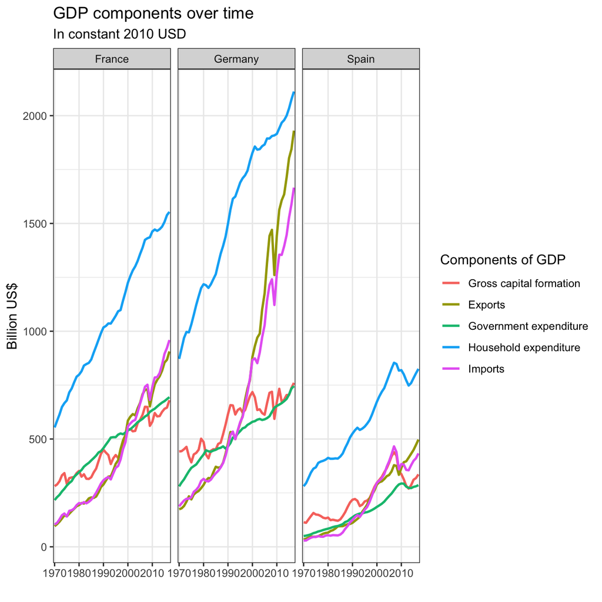

What is the % difference between what we calculated as GDP and the GDP figure included in the dataframe?

```
## Mean difference between calculated and given GDPs:
##  0.00398
```

Perhaps this mean difference arises from reporting standards and currency rates, resulting in different calculations for each country.

We will now break down GDP as the sum of Household Expenditure (Consumption *C*), Gross Capital Formation (business investment *I*), Government Expenditure (G) and Net Exports (exports - imports).

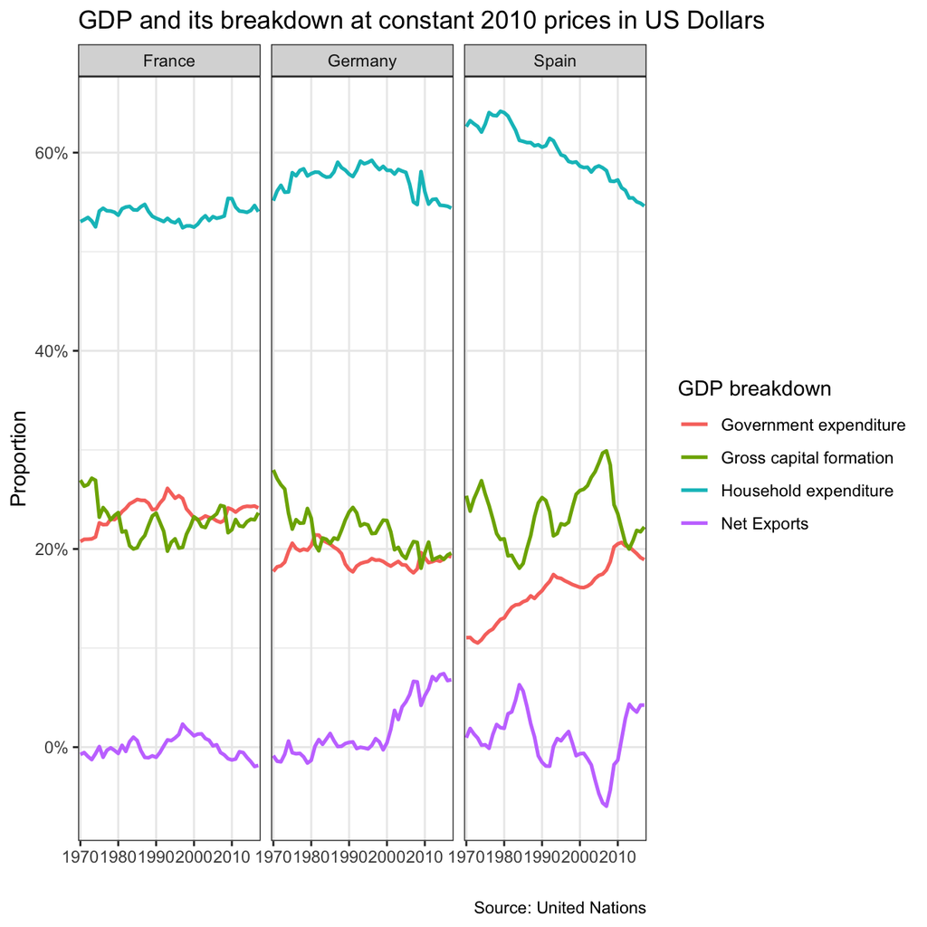

# Some Findings